# UFPR PPGEcon 2024

Estatística (Prof. Adalto Acir Althaus Jr.): exercícios

Alceu Nascimento, João Maurício Rolim e Tiago Soares

2024-04-21

# Exerício 05

## Questão A

(só observar)

## Questão B

Ajuste uma reta de regressão para os dados, calcule o coeficiente de determinação e construa um intervalo de 95% de confiança para $β_0$ e $β_1$.  
Analise as premissas do modelo de regressão.

```r
# carregando o dataset
# path_b = "C:/Users/DELL/OneDrive/R/Rprojetos/ufpr_ppgecon/estatistica/data/dataset5b.csv"
path_b = "~/proj/ufpr_ppgecon/estatistica/data/dataset5b.csv"
dfb <- read_csv2(path_b)
head(dfb)
```

```
## # A tibble: 6 × 2
##   anos_estudo salario_medio
##         <dbl>         <dbl>
## 1           6         44567
## 2           7         57700
## 3           8         59787
## 4           9         73317
## 5          10         73182
## 6          11         65844
```

```r
rm(path_b)
```

```r
model.5b <- lm(salario_medio ~ anos_estudo, data = dfb)
summary(model.5b)
```

```
##
## Call:
## lm(formula = salario_medio ~ anos_estudo, data = dfb)
##
## Residuals:
##        Min         1Q     Median         3Q        Max
## -15637.044  -7349.945   1265.725   7157.758  13198.088
##
## Coefficients:
##              Estimate Std. Error  t value      Pr(>|t|)
## (Intercept) -144.5275  8746.2392 -0.01652       0.98711
## anos_estudo 7240.9670   695.8134 10.40648 0.00000049579 ***
## ---
## Signif. codes:  0 '***' 0.001 '**' 0.01 '*' 0.05 '.' 0.1 ' ' 1
##
## Residual standard error: 9387.036 on 11 degrees of freedom
## Multiple R-squared:  0.9077914,  Adjusted R-squared:  0.8994088
## F-statistic: 108.2948 on 1 and 11 DF,  p-value: 0.0000004957885
```

```r
# checks
check_autocorrelation(model.5b)
```

```
## OK: Residuals appear to be independent and not autocorrelated (p = 0.384).
```

```r
check_collinearity(model.5b)
```

```r
check_normality(model.5b)
```

```
## OK: residuals appear as normally distributed (p = 0.620).
```

```r
check_heteroscedasticity(model.5b)
```

```
## OK: Error variance appears to be homoscedastic (p = 0.490).
```

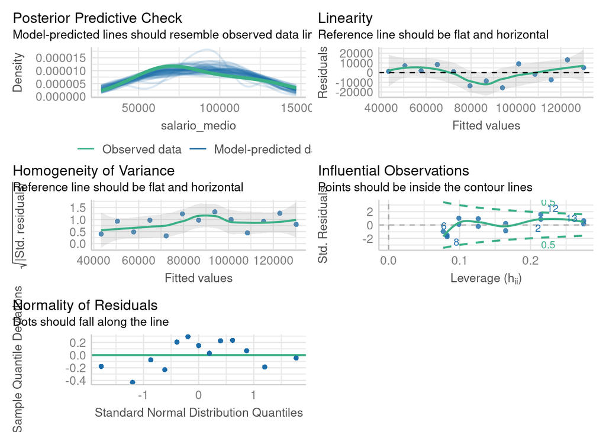

```r
check_model(model.5b)
```

```r
stargazer(model.5b, type = "html",  digits=2, report = "vcstp")
```

|  | *Dependent variable:* |
| --- | --- |
|  | salario_medio |
| anos_estudo | 7,240.97 |
|  | (695.81) |
|  | t = 10.41 |
|  | p = 0.0000 |
| Constant | -144.53 |
|  | (8,746.24) |
|  | t = -0.02 |
|  | p = 0.99 |
| Observations | 13 |
| R<sup>2</sup> | 0.91 |
| Adjusted R<sup>2</sup> | 0.90 |
| Residual Std. Error | 9,387.04 (df = 11) |
| F Statistic | 108.29*** (df = 1; 11) |
| *Note:* | p<0.1; p<0.05; p<0.01 |

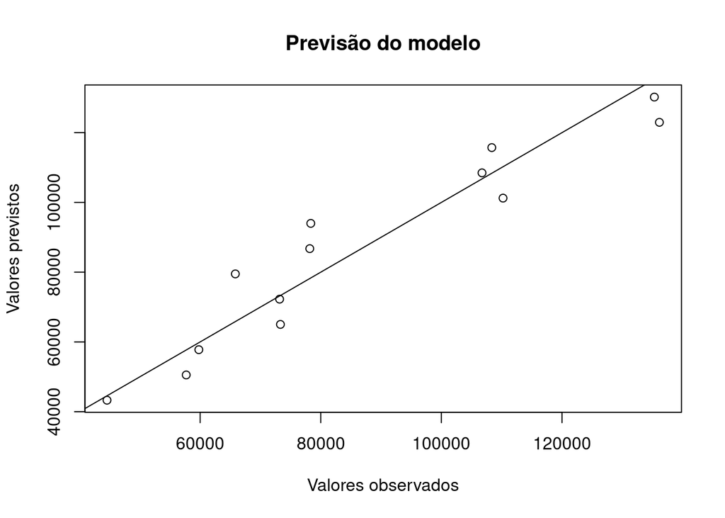

```r
plot(x = dfb$salario_medio,
     y = model.5b$fitted.values,
     xlab = "Valores observados",
     ylab = "Valores previstos",
     main = "Previsão do modelo")
abline(b = 1, a = 0)
```

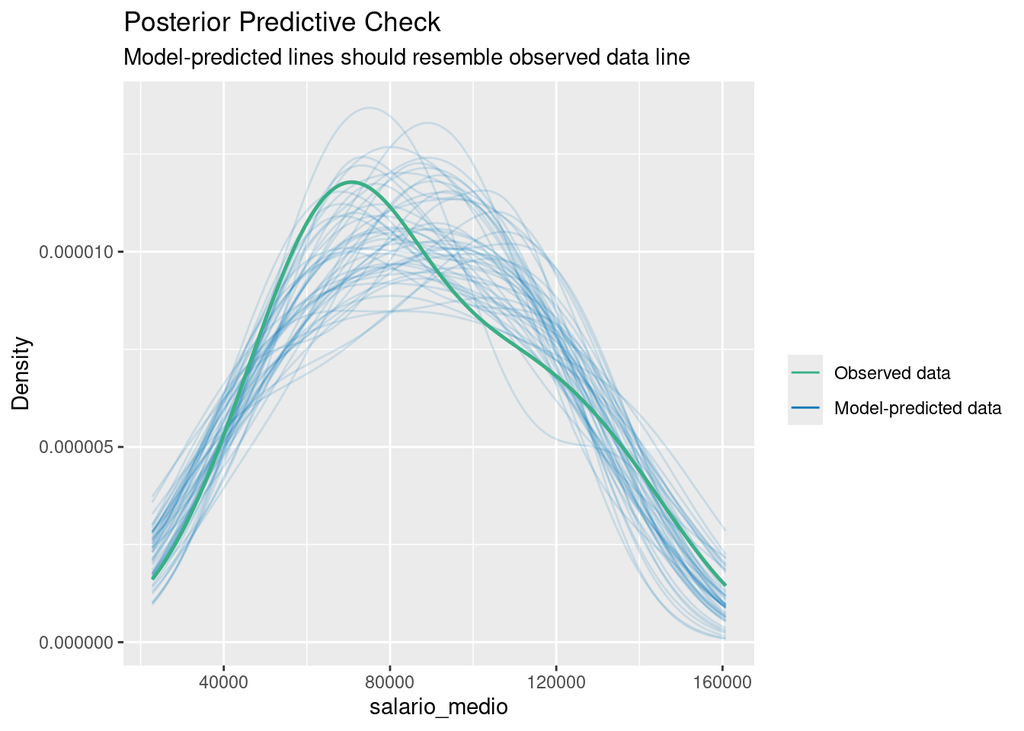

```r
previsto.5b <- check_predictions(model.5b)
plot(previsto.5b)
```

```r
confint(model.5b, level=0.95)
```

```
##                     2.5 %       97.5 %
## (Intercept) -19394.870079 19105.815134
## anos_estudo   5709.492005  8772.442061
```

## Questão C (dataset “aptos”)

A planilha Aptos traz os dados de 50 apartamentos, onde temos seus respectivos preço de venda, em reais, idade, em anos e área, em $m^2$.

Vamos construir um modelo de regressão no qual a variável dependente $(Y)$ preço será explicada pelas variáveis independentes $(X_1)$ idade do imóvel e $(X_2)$ área do imóvel.

```r
# carregando o dataset
# path_c = "C:/Users/DELL/OneDrive/R/Rprojetos/ufpr_ppgecon/estatistica/data/dataset5c.csv"
path_c = "~/proj/ufpr_ppgecon/estatistica/data/dataset5c.csv"
dfc <- read_csv2(path_c)
head(dfc)
```

```
## # A tibble: 6 × 3
##    preco  area idade
##    <dbl> <dbl> <dbl>
## 1 268380   189     1
## 2 131000   115    15
## 3 112000   102    35
## 4 112000    93    35
## 5 122000   123    39
## 6 127900   124    32
```

```r
rm(path_c)
```

```r
model.5c <- lm(preco ~ idade + area, data = dfc)
summary(model.5c)
```

```
##
## Call:
## lm(formula = preco ~ idade + area, data = dfc)
##
## Residuals:
##        Min         1Q     Median         3Q        Max
## -41484.158 -15686.170    615.096  10390.855  78273.513
##
## Coefficients:
##                Estimate  Std. Error  t value            Pr(>|t|)
## (Intercept) 62488.21953 13411.90182  4.65916 0.00002636010312901 ***
## idade        -804.60423   126.37649 -6.36672 0.00000007481930470 ***
## area          742.05779    71.83778 10.32963 0.00000000000011127 ***
## ---
## Signif. codes:  0 '***' 0.001 '**' 0.01 '*' 0.05 '.' 0.1 ' ' 1
##
## Residual standard error: 22518.34 on 47 degrees of freedom
## Multiple R-squared:  0.8363525,  Adjusted R-squared:  0.8293888
## F-statistic: 120.1014 on 2 and 47 DF,  p-value: < 2.2204e-16
```

```r
# checks
check_autocorrelation(model.5c)
```

```
## OK: Residuals appear to be independent and not autocorrelated (p = 0.656).
```

```r
check_collinearity(model.5c)
```

```
## # Check for Multicollinearity
##
## Low Correlation
##
##   Term  VIF   VIF 95% CI Increased SE Tolerance Tolerance 95% CI
##  idade 1.20 [1.03, 2.14]         1.09      0.84     [0.47, 0.97]
##   area 1.20 [1.03, 2.14]         1.09      0.84     [0.47, 0.97]
```

```r
check_normality(model.5c)
check_heteroscedasticity(model.5c)
```

[output not shown]

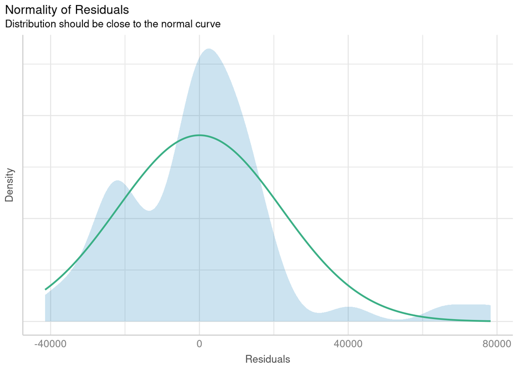

```r
# verificando ausencia de normalidade dos residuos
normal.res.5c <- check_normality(model.5c)
plot(normal.res.5c, type = "density")
```

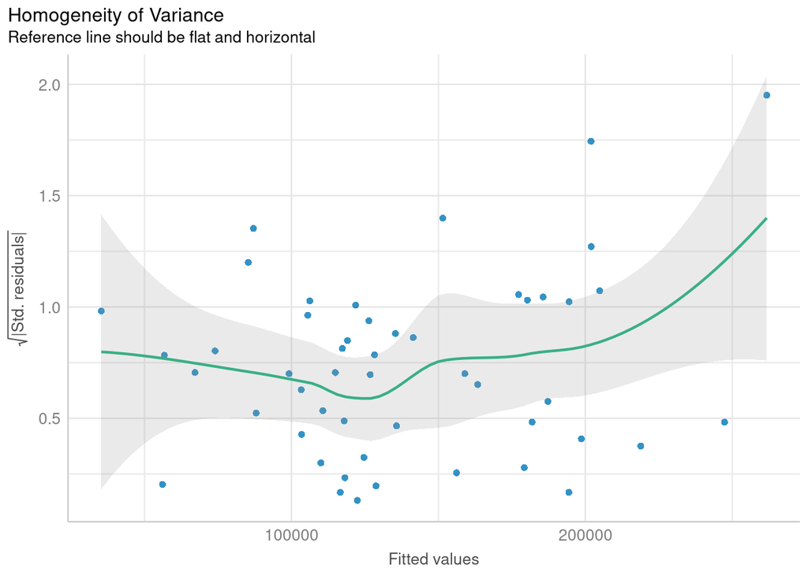

```r
# verificando heteroscedasticidade
hetero.5c <- check_heteroscedasticity(model.5c)
plot(hetero.5c)
```

```r
stargazer(model.5c, type = "html", digits=3, report = "vcstp")
```

|  | *Dependent variable:* |
| --- | --- |
|  | preco |
| idade | -804.604 |
|  | (126.376) |
|  | t = -6.367 |
|  | p = 0.00000 |
| area | 742.058 |
|  | (71.838) |
|  | t = 10.330 |
|  | p = 0.000 |
| Constant | 62,488.220 |
|  | (13,411.902) |
|  | t = 4.659 |
|  | p = 0.00003 |
| Observations | 50 |
| R<sup>2</sup> | 0.836 |
| Adjusted R<sup>2</sup> | 0.829 |
| Residual Std. Error | 22,518.342 (df = 47) |
| F Statistic | 120.101*** (df = 2; 47) |
| *Note:* | p<0.1; p<0.05; p<0.01 |

O modelo ficou assim:

$$\hat{Y}_{preço} = \hat{\beta_o} + \hat{\beta_1} X_{idade} +
\hat{\beta_2} X_{área} \\
\hat{Y}_{preço} =
62488.22
-804.6 X_{idade} +
742.06 X_{área}$$

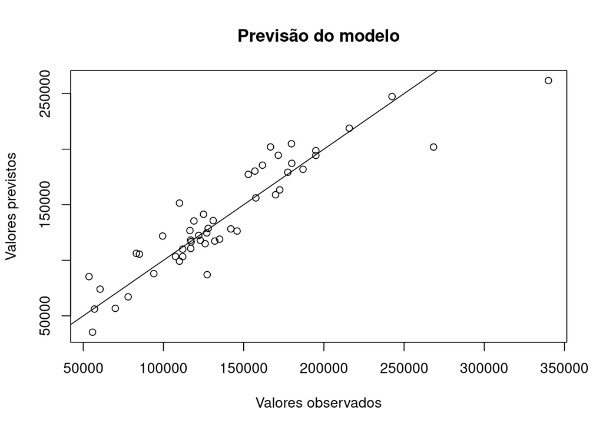

```r
plot(x = dfc$preco,
     y = model.5c$fitted.values,
     xlab = "Valores observados",
     ylab = "Valores previstos",
     main = "Previsão do modelo")
abline(b = 1, a = 0)
```

### a) Calcule o $R2$ e interprete seu significado.

```r
summary(model.5c)$r.squared
```

```
## [1] 0.8363525406
```

```r
summary(model.5c)$adj.r.squared
```

```
## [1] 0.8293888189
```

### b) Forneça as hipóteses testadas na ANOVA e a conclusão obtida.

```r
anova(model.5c)
```

```
## Analysis of Variance Table
##
## Response: preco
##           Df      Sum Sq     Mean Sq   F value     Pr(>F)
## idade      1 67695352683 67695352683 133.50146 2.4718e-15 ***
## area       1 54105631667 54105631667 106.70128 1.1127e-13 ***
## Residuals 47 23832559451   507075733
## ---
## Signif. codes:  0 '***' 0.001 '**' 0.01 '*' 0.05 '.' 0.1 ' ' 1
```

### c) Deixe claro o significado de cada parâmetro e forneça um intervalo de 95% de confiança.

```r
confint(model.5c)
```

```
##                     2.5 %        97.5 %
## (Intercept) 35506.9532709 89469.4857796
## idade       -1058.8409375  -550.3675210
## area          597.5388193   886.5767678
```

Cada 1 ano de idade, o preço reduz -804.6. Para cada 1$m^2$ de área, o preço do imóvel aumenta 742.06

### d) Qual o preço previsto para um apartamento com 10 anos de vida e 200 metros quadrados?

```r
# Novos dados
dfc.novo <- data.frame(idade = c(10),
                       area = c(200)
                       )

preco.novo <- predict(object = model.5c,     # O modelo
                      newdata = dfc.novo,   # Os novos dados
                      interval = "confidence",
                      level = 0.95)
```

Do resultado, é possível afirmar que o preço estimado para o apartamento é de 202853.74.  
O intervalo de confiança (192328.38, 213379.09) indica os valores que o parametro adota na população, no nível de confiança de 95%.

Para verificar a qualidade do modelo podemos observar:

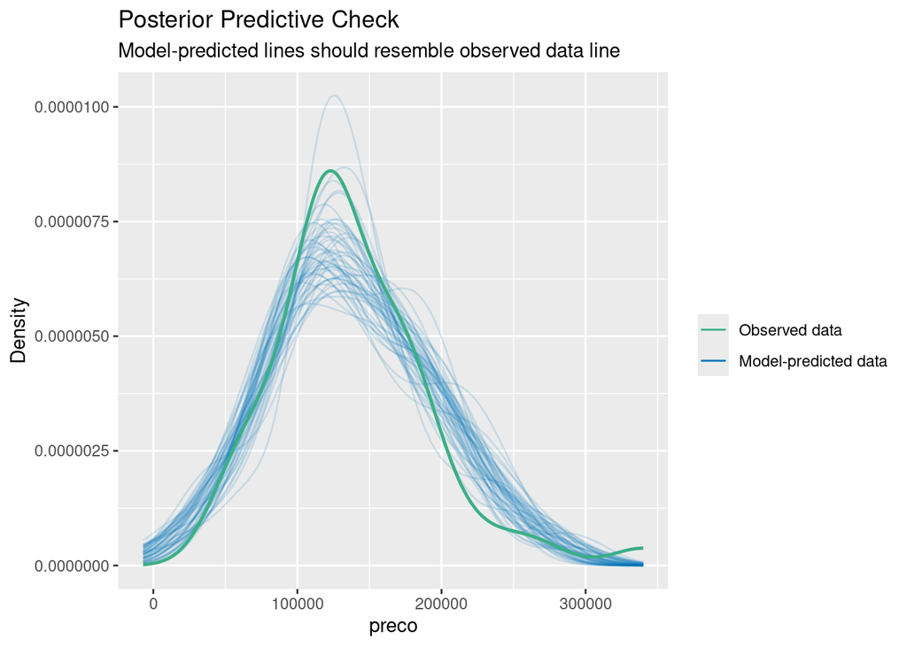

```r
previsto.5c <- check_predictions(model.5c)
plot(previsto.5c)
```

### e) Analise as premissas do modelo.

O modelo não atender as premissada, dada a heteocedasticidade e ausencia de normalidade dos resíduos.

## Questão D (dataset “futebol”)

A planilha Futebol apresenta o resultado do Brasileirão de 20xx, sendo:  
P pontos - J jogos - V vitórias - E empates - D derrotas - GP gols pró - GC gols contra - SG saldo de gols - VM vitória mandante - VV vitória visitante - DM Derrota mandante - DV Derrota visitante - CA cartões amarelos - CV cartões vermelhos

Ajuste modelos de regressão linear para explicar a pontuação.

```r
# carregando o dataset
#path_d = "C:/Users/DELL/OneDrive/R/Rprojetos/ufpr_ppgecon/estatistica/data/dataset5d.csv"
path_d = "~/proj/ufpr_ppgecon/estatistica/data/dataset5d.csv"

dfd <- read_csv2(path_d)
head(dfd)
```

```
## # A tibble: 6 × 15
##   CLASSIFICAÇÃO          P     J     V     E     D    GP    GC    SG    VM    VV
##   <chr>              <dbl> <dbl> <dbl> <dbl> <dbl> <dbl> <dbl> <dbl> <dbl> <dbl>
## 1 Fluminense - RJ       77    38    22    11     5    61    33    28    11    11
## 2 Atlético - MG         72    38    20    12     6    64    37    27    14     6
## 3 Grêmio - RS           71    38    20    11     7    56    33    23    13     7
## 4 São Paulo - SP        66    38    20     6    12    59    37    22    15     5
## 5 Vasco da Gama - RJ    58    38    16    10    12    45    44     1     9     7
## 6 Corinthians - SP      57    38    15    12    11    51    39    12    10     5
## # ℹ 4 more variables: DM <dbl>, DV <dbl>, CA <dbl>, CV <dbl>
```

```r
glimpse(dfd)
```

```
## Rows: 20
## Columns: 15
## $ CLASSIFICAÇÃO <chr> "Fluminense - RJ", "Atlético - MG", "Grêmio - RS", "São …
## $ P             <dbl> 77, 72, 71, 66, 58, 57, 55, 53, 52, 52, 50, 49, 48, 48, …
## $ J             <dbl> 38, 38, 38, 38, 38, 38, 38, 38, 38, 38, 38, 38, 38, 38, …
## $ V             <dbl> 22, 20, 20, 20, 16, 15, 15, 13, 15, 13, 12, 14, 14, 12, …
## $ E             <dbl> 11, 12, 11, 6, 10, 12, 10, 14, 7, 13, 14, 7, 6, 12, 14, …
## $ D             <dbl> 5, 6, 7, 12, 12, 11, 13, 11, 16, 12, 12, 17, 18, 14, 13,…
## $ GP            <dbl> 61, 64, 56, 59, 45, 51, 60, 50, 47, 44, 39, 44, 53, 37, …
## $ GC            <dbl> 33, 37, 33, 37, 44, 39, 50, 44, 51, 40, 46, 51, 60, 44, …
## $ SG            <dbl> 28, 27, 23, 22, 1, 12, 10, 6, -4, 4, -7, -7, -7, -7, -4,…
## $ VM            <dbl> 11, 14, 13, 15, 9, 10, 9, 8, 9, 9, 8, 13, 11, 9, 5, 7, 7…
## $ VV            <dbl> 11, 6, 7, 5, 7, 5, 6, 5, 6, 4, 4, 1, 3, 3, 6, 3, 3, 3, 2…
## $ DM            <dbl> 3, 0, 2, 2, 6, 3, 6, 2, 5, 6, 3, 3, 6, 3, 5, 4, 6, 8, 11…
## $ DV            <dbl> 2, 6, 5, 10, 6, 8, 7, 9, 11, 6, 9, 14, 12, 11, 8, 9, 11,…
## $ CA            <dbl> 85, 104, 102, 93, 91, 87, 75, 82, 121, 106, 81, 86, 99, …
## $ CV            <dbl> 3, 10, 9, 6, 3, 3, 3, 4, 9, 6, 6, 6, 7, 2, 2, 4, 8, 6, 6…
```

```r
rm(path_d)
```

```r
model.5d <- lm(P ~  GP + GC + VV, data = dfd)
summary(model.5d)
```

```
##
## Call:
## lm(formula = P ~ GP + GC + VV, data = dfd)
##
## Residuals:
##       Min        1Q    Median        3Q       Max
## -6.614977 -2.674783  1.206002  1.812690  5.011047
##
## Coefficients:
##                Estimate  Std. Error  t value    Pr(>|t|)
## (Intercept) 43.43753180  7.75026862  5.60465 0.000039513 ***
## GP           0.68454480  0.11051629  6.19406 0.000012868 ***
## GC          -0.59783685  0.09801697 -6.09932 0.000015362 ***
## VV           0.92112927  0.51057931  1.80409    0.090076 .
## ---
## Signif. codes:  0 '***' 0.001 '**' 0.01 '*' 0.05 '.' 0.1 ' ' 1
##
## Residual standard error: 3.393531 on 16 degrees of freedom
## Multiple R-squared:  0.9421258,  Adjusted R-squared:  0.9312744
## F-statistic: 86.82063 on 3 and 16 DF,  p-value: 0.0000000004092179
```

```r
# checks
check_autocorrelation(model.5d)
```

```
## OK: Residuals appear to be independent and not autocorrelated (p = 0.248).
```

```r
check_collinearity(model.5d)
```

```
## # Check for Multicollinearity
##
## Low Correlation
##
##  Term  VIF   VIF 95% CI Increased SE Tolerance Tolerance 95% CI
##    GP 1.68 [1.23, 2.97]         1.30      0.60     [0.34, 0.81]
##    GC 1.81 [1.30, 3.19]         1.35      0.55     [0.31, 0.77]
##    VV 2.28 [1.55, 4.01]         1.51      0.44     [0.25, 0.65]
```

```r
check_normality(model.5d)
```

```
## OK: residuals appear as normally distributed (p = 0.485).
```

```r
check_heteroscedasticity(model.5d)
```

```
## OK: Error variance appears to be homoscedastic (p = 0.579).
```

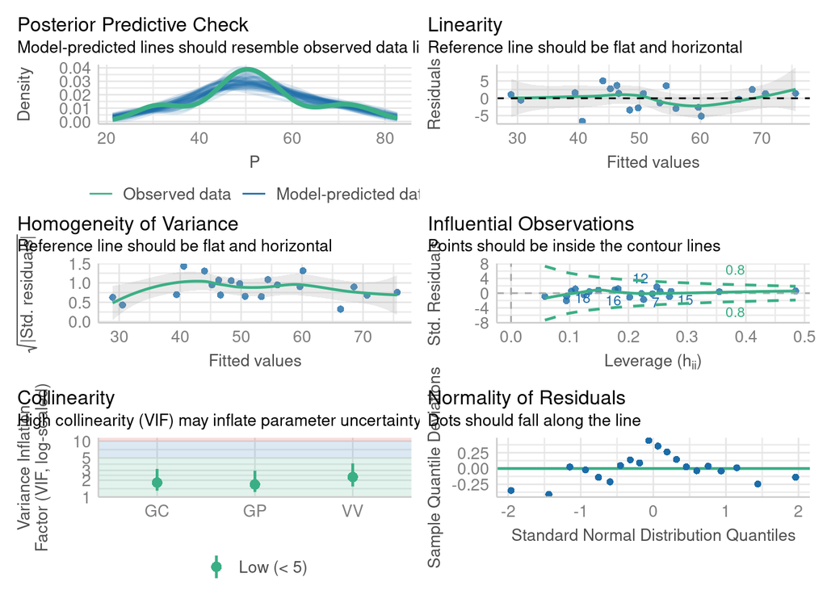

```r
check_model(model.5d)
```

```r
stargazer(model.5d, type = "html", digits=3, report = "vcstp")
```

|  | *Dependent variable:* |
| --- | --- |
|  | P |
| GP | 0.685 |
|  | (0.111) |
|  | t = 6.194 |
|  | p = 0.00002 |
| GC | -0.598 |
|  | (0.098) |
|  | t = -6.099 |
|  | p = 0.00002 |
| VV | 0.921 |
|  | (0.511) |
|  | t = 1.804 |
|  | p = 0.091 |
| Constant | 43.438 |
|  | (7.750) |
|  | t = 5.605 |
|  | p = 0.00004 |
| Observations | 20 |
| R<sup>2</sup> | 0.942 |
| Adjusted R<sup>2</sup> | 0.931 |
| Residual Std. Error | 3.394 (df = 16) |
| F Statistic | 86.821*** (df = 3; 16) |
| *Note:* | p<0.1; p<0.05; p<0.01 |

## Questão E (dataser “acidentes”)

| Variavel | Descrição |
| --- | --- |
| state | Nome do Estado |
| pay94 | Renda média em 20xx |
| pop | População em 20xx |
| area | Área do Estado em Milhas quadradas |
| density | População por milha quadrada |
| ins94 | Médias dos seguros de automóveis em 20xx |
| carsins | Números de carros segurados em 20xx |
| regist | Número de carros registrados em 20xx |
| rdmiles | Milhas de estradas |
| fia | Total de Acidentes Fatais |
| bac | Limite da quantidade de álcool no sangue |
| totdriv | Total de motoristas licenciados em 20xx |

```r
# carregando o dataset
#path_e = "C:/Users/DELL/OneDrive/R/Rprojetos/ufpr_ppgecon/estatistica/data/dataset5e.csv"
path_e = "~/proj/ufpr_ppgecon/estatistica/data/dataset5e.csv"

dfe <- read_csv2(path_e)
head(dfe)
```

```
## # A tibble: 6 × 12
##   state   pay94    pop   area density ins94 carsins regist rdmiles   bac totdriv
##   <chr>   <dbl>  <dbl>  <dbl>   <dbl> <dbl>   <dbl>  <dbl>   <dbl> <dbl>   <dbl>
## 1 Alabama 23616 4.04e6 5.08e4    79.6  611.  2.11e6 3.74e6   90672  0.1   2.75e6
## 2 Alaska  32657 5.50e6 5.70e5     1    878.  2.76e5 4.77e5   13485  0.1   3.14e5
## 3 Arizona 24276 3.67e6 1.14e5    32.3  810.  2.15e6 2.83e6   51612  0.1   2.39e6
## 4 Arkans… 20898 2.35e6 5.21e4    45.1  612.  1.57e6 1.45e6   77085  0.1   1.72e6
## 5 Califo… 29878 2.98e7 1.56e5   191.   887.  1.40e7 2.19e7  163574  0.08  1.98e7
## 6 Colora… 26164 3.29e6 1.04e5    31.8  823.  2.21e6 3.16e6   77680  0.1   2.04e6
## # ℹ 1 more variable: fia <dbl>
```

```r
rm(path_e)
```

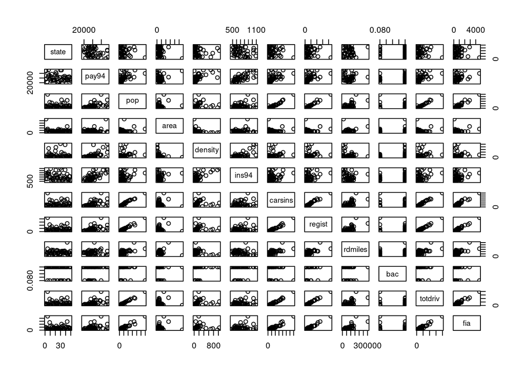

```r
plot(dfe)
```

```r
model.5e <- lm(ins94 ~ fia + pay94 + regist, data = dfe)
summary(model.5e)
```

```
##
## Call:
## lm(formula = ins94 ~ fia + pay94 + regist, data = dfe)
##
## Residuals:
##        Min         1Q     Median         3Q        Max
## -190.54480  -57.66024  -18.50309   54.79143  306.28625
##
## Coefficients:
##                     Estimate       Std. Error  t value         Pr(>|t|)
## (Intercept) -386.15402403615  133.28575432947 -2.89719        0.0057477 **
## fia            0.32962351239    0.11243140744  2.93177        0.0052358 **
## pay94          0.04474580321    0.00554951557  8.06301 0.00000000023884 ***
## regist        -0.00007682588    0.00002507879 -3.06338        0.0036520 **
## ---
## Signif. codes:  0 '***' 0.001 '**' 0.01 '*' 0.05 '.' 0.1 ' ' 1
##
## Residual standard error: 105.674 on 46 degrees of freedom
## Multiple R-squared:  0.6174465,  Adjusted R-squared:  0.5924974
## F-statistic: 24.74821 on 3 and 46 DF,  p-value: 0.000000001104133
```

```r
# checks
check_autocorrelation(model.5e)
```

```
## OK: Residuals appear to be independent and not autocorrelated (p = 0.498).
```

```r
check_collinearity(model.5e)
```

```
## # Check for Multicollinearity
##
## Low Correlation
##
##   Term  VIF     VIF 95% CI Increased SE Tolerance Tolerance 95% CI
##  pay94 1.74 [ 1.33,  2.67]         1.32      0.57     [0.37, 0.75]
##
## High Correlation
##
##    Term   VIF     VIF 95% CI Increased SE Tolerance Tolerance 95% CI
##     fia 38.69 [24.06, 62.59]         6.22      0.03     [0.02, 0.04]
##  regist 42.29 [26.28, 68.43]         6.50      0.02     [0.01, 0.04]
```

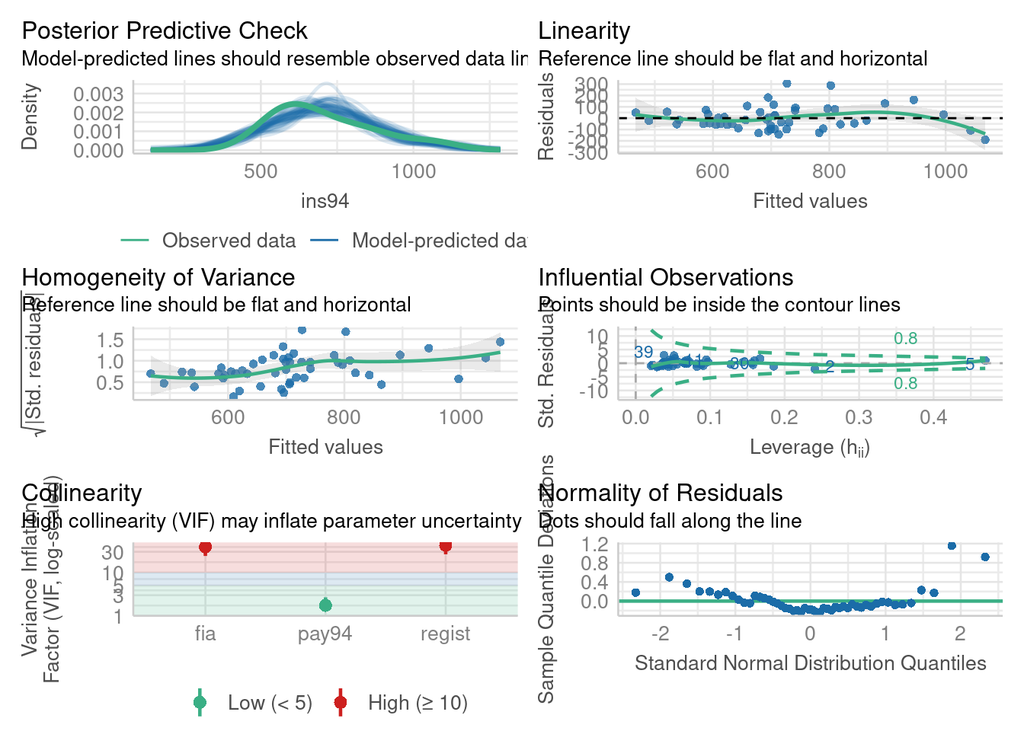

```r
check_normality(model.5e)
check_heteroscedasticity(model.5e)
check_model(model.5e)
```

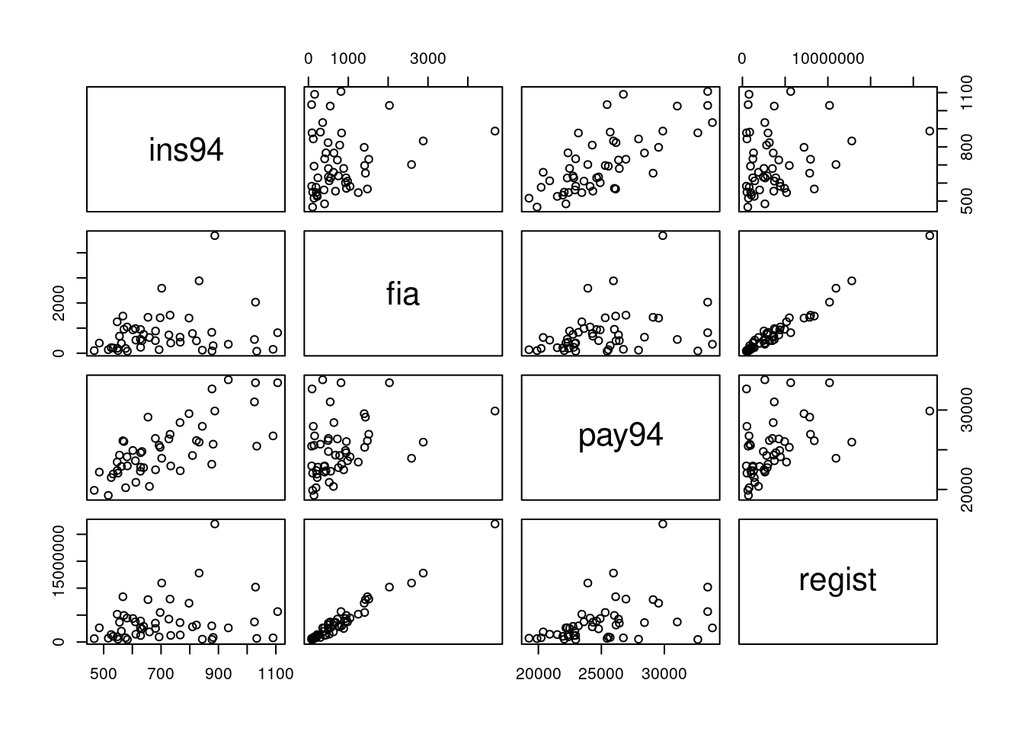

```r
dfe_lm <- dfe %>%
  select(ins94, fia, pay94, regist)
plot(dfe_lm)
```

```r
stargazer(model.5e, type = "html", digits=3, report = "vcstp")
```

|  | *Dependent variable:* |
| --- | --- |
|  | ins94 |
| fia | 0.330 |
|  | (0.112) |
|  | t = 2.932 |
|  | p = 0.006 |
| pay94 | 0.045 |
|  | (0.006) |
|  | t = 8.063 |
|  | p = 0.000 |
| regist | -0.0001 |
|  | (0.00003) |
|  | t = -3.063 |
|  | p = 0.004 |
| Constant | -386.154 |
|  | (133.286) |
|  | t = -2.897 |
|  | p = 0.006 |
| Observations | 50 |
| R<sup>2</sup> | 0.617 |
| Adjusted R<sup>2</sup> | 0.592 |
| Residual Std. Error | 105.674 (df = 46) |
| F Statistic | 24.748*** (df = 3; 46) |
| *Note:* | p<0.1; p<0.05; p<0.01 |